# Project Interim Report

# Project Title

Weather Image Classification

# Project Authors

Isabella Toth, Nicole Marcatoma, Sana Nanlawala

# Introduction

Automated weather classification from images has practical applications and value for environmental monitoring, transportation safety, agriculture, and disaster preparations. These organizations often need to know weather conditions in real time, and manually labeling weather images is slow and inconsistent. A deep learning model that can automatically classify weather scenes would make this process faster and more reliable. To address this problem, our project uses Convolution Neural Networks (CNNs) to classify images from the Weather Phenomenon Database (WEAPD) into 11 distinct weather categories. CNNs are ideal for this task as they automatically learn spatial and texture-based features (such as cloud density, snow fall patterns, sunlight, etc.) that help distinguish one type of weather condition from another and make accurate image classification decisions.

# Problem Statement

The problem we seek to solve with our project is the creation of a deep learning model capable of identifying the type of weather shown in an image, classifying it into one of eleven different categories: dew, fog/smog, frost, glaze, hail, lightning, rain, rainbow, rime, sandstorm, and snow. We plan on using the WEAPD data sourced from Kaggle and compiled by Haizia Xiao in 2021 from the Harvard Dataverse. This dataset is made up of 6,862 images of different types of weather conditions. The links to the dataset are as follows:

Kaggle Dataset Source:  
[Weather Dataset on Kaggle](https://www.kaggle.com/datasets/jehanbhathena/weather-dataset)

Original Dataset Source:  
[Harvard Dataverse Dataset](https://dataverse.harvard.edu/dataset.xhtml?persistentId=doi:10.7910/DVN/M8JQCR)

As previously stated, this project will involve deep learning to create an image classification model that classifies the type of weather depicted in the WEAPD image dataset. We will use classification metrics such as accuracy, precision, and recall for model performance evaluation. We also plan on creating a confusion matrix as it is an intuitive and easily interpretable qualitative summary of the model’s results that can be shared with others.

# Technical Approach

Our project will involve creating a deep learning workflow for weather image classification. Looking at the images provided in the dataset, the sizes of each image varies, meaning standardization will be needed—possibly following the averages of width and height, or a generic 1-to-1 sizing. Alongside that, augmentation to account for rotation/flips, brightness levels, etc. will be needed. These preliminary steps will guide the CNN (Convolutional Neural Networks) models we will create for classification, as these models recognize spatial patterns (textures, lines, shapes) to help classify images. Following a baseline model to set up standards for our accuracy metric, we will try various deep learning techniques to improve the model and the complexity required for this dataset. This will include regularization techniques such as dropout, batch normalization, and early stopping, as well as various optimizers. We will begin with the Adam optimizer but might adapt to implementing other optimization methods such as SGD, if needed. For more understanding, the usage of correlation matrices will help inform more class-based discrepancies in predictions.

# Preliminary Results

The dataset consists of 6,862 images spanning 11 weather categories, including dew, fogsmog, frost, glaze, hail, lightning, rain, rainbow, rime, sandstorm, and snow. Images were preprocessed by resizing to 64 x 64 pixels and normalized, and the dataset was split into 80% training and 20% validation subsets. To establish a baseline for weather classification, a simple convolutional neural network was implemented, consisting of two convolutional layers, followed by a fully connected hidden layer and an output layer corresponding to the 11 classes. The model was trained using the Adam optimizer with a learning rate of 0.001 and a batch size of 32 for five epochs. Over the course of training, the loss decreased steadily from 1.38 to 0.60, indicating that the network was able to extract meaningful features from the images. On the validation set, the baseline model achieved an accuracy of 71.6%, providing a reference performance for future improvements.

# Next Steps

Examination of the class distribution revealed some imbalance, with certain categories underrepresented, and preliminary inspection of the confusion matrix suggested that visually similar classes were more frequently misclassified. These results demonstrate that even a minimal CNN is capable of capturing useful patterns for weather classification, establishing a foundation for subsequent experiments. Future enhancements may include data augmentation to increase model robustness, deeper or more sophisticated network architectures as explained earlier in the technical approach, transfer learning with pretrained networks such as ResNet, and hyperparameter optimization to improve overall accuracy.

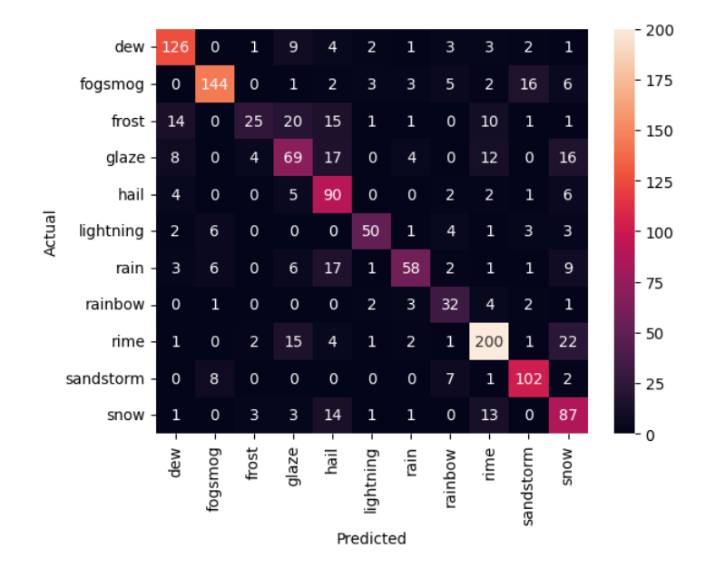

Baseline Results